We will start with reading in the dataset

# Udacity - Seattle’s Airbnb Data Analysis Project

## 1. Business Understanding

The Seattle AirBnB Dataset contains data about AirBnB listings in Seattle, calendar availability for each of these listings as well as user reviews on the listings. Using this dataset, I am going to attempt to answer the following business questions.

Who are the top performers in Airbnb business? What listing features are highly correlated to the listing performance? What are the advices a landlord can take to improve their listing performances? Which neighbourhood has higher listing prices for investors to consider?

Pricing trend related questions can help understand peak seasons and neighborhood in Seattle and can allow AirBnB to regulate inventory accordingly. It can also help with targeting more effective marketing campaigns.

Sentiment analysis of reviews can give AirBnB insight into brand affinity and gauge consumer interest. In addition, associating the sentiments with neighborhoods can detect problematic neighborhoods.

Price prediction can help understand what factors mostly correlate with price. This is helpful so these features can be top of mind for AirBnB as well as AirBnB hosts.

## 2. Data Understanding

As a first step, I will be reading the 3 files part of the Seattle AirBnB dataset and exploring each of the datasets a bit.

```python
import numpy as np
import pandas as pd
import matplotlib.pyplot as plt
from sklearn.linear_model import LinearRegression
from sklearn.model_selection import train_test_split
from sklearn.metrics import r2_score, mean_squared_error
import seaborn as sns
%matplotlib inline

#seattle data path"
s_cal_path="C:/Users/gyang/Documents/DS/Udacity_Airbnb_project/seattle_airbnb_data/calendar.csv"
s_lst_path="C:/Users/gyang/Documents/DS/Udacity_Airbnb_project/seattle_airbnb_data/listings.csv"
s_rev_path="C:/Users/gyang/Documents/DS/Udacity_Airbnb_project/seattle_airbnb_data/reviews.csv"

df_s_calender=pd.read_csv(s_cal_path,header=0)
df_s_list=pd.read_csv(s_lst_path,header=0)
df_rev_list=pd.read_csv(s_rev_path,header=0)
df_s_list.columns = (df_s_list.columns.str.strip().str.replace(' ', '_')
              .str.replace('(', '')
              .str.replace(')', ''))
```

```python
from collections import Counter
from scipy.stats.stats import pearsonr
from string import ascii_letters

import warnings
import plotly.graph_objs as go
from plotly.offline import init_notebook_mode, iplot
from plotly import tools
from function import *
init_notebook_mode(connected=True)

pd.set_option('display.max_columns', 500)
warnings.filterwarnings('ignore')
```

```python
df_s_calender.head()
```

|  | listing_id | date | available | price |
| --- | --- | --- | --- | --- |
| 0 | 241032 | 2016-01-04 | t | $85.00 |
| 1 | 241032 | 2016-01-05 | t | $85.00 |
| 2 | 241032 | 2016-01-06 | f | NaN |
| 3 | 241032 | 2016-01-07 | f | NaN |
| 4 | 241032 | 2016-01-08 | f | NaN |

```python
df_s_list.head()
```

|  | id | listing_url | scrape_id | last_scraped | name | summary | space | description | experiences_offered | neighborhood_overview | notes | transit | thumbnail_url | medium_url | picture_url | xl_picture_url | host_id | host_url | host_name | host_since | host_location | host_about | host_response_time | host_response_rate | host_acceptance_rate | host_is_superhost | host_thumbnail_url | host_picture_url | host_neighbourhood | … |
| --- | --- | --- | --- | --- | --- | --- | --- | --- | --- | --- | --- | --- | --- | --- | --- | --- | --- | --- | --- | --- | --- | --- | --- | --- | --- | --- | --- | --- | --- | --- |
| 0 | 241032 | https://www.airbnb.com/rooms/241032 | 20160104002432 | 2016-01-04 | Stylish Queen Anne Apartment | NaN | Make your self at home in this charming one-be... | Make your self at home in this charming one-be... | none | NaN | NaN | NaN | NaN | NaN | https://a1.muscache.com/ac/pictures/67560560/c... | NaN | 956883 | https://www.airbnb.com/users/show/956883 | Maija | 2011-08-11 | Seattle, Washington, United States | I am an artist, interior designer, and run a s... | within a few hours | 96% | 100% | f | https://a0.muscache.com/ac/users/956883/profil... | https://a0.muscache.com/ac/users/956883/profil... | Queen Anne | … |
| 1 | 953595 | https://www.airbnb.com/rooms/953595 | 20160104002432 | 2016-01-04 | Bright & Airy Queen Anne Apartment | Chemically sensitive? We've removed the irrita... | Beautiful, hypoallergenic apartment in an extr... | Chemically sensitive? We've removed the irrita... | none | Queen Anne is a wonderful, truly functional vi... | What's up with the free pillows? Our home was... | Convenient bus stops are just down the block, ... | https://a0.muscache.com/ac/pictures/14409893/f... | https://a0.muscache.com/im/pictures/14409893/f... | https://a0.muscache.com/ac/pictures/14409893/f... | https://a0.muscache.com/ac/pictures/14409893/f... | 5177328 | https://www.airbnb.com/users/show/5177328 | Andrea | 2013-02-21 | Seattle, Washington, United States | Living east coast/left coast/overseas. Time i... | within an hour | 98% | 100% | t | https://a0.muscache.com/ac/users/5177328/profi... | https://a0.muscache.com/ac/users/5177328/profi... | Queen Anne | … |
| 2 | 3308979 | https://www.airbnb.com/rooms/3308979 | 20160104002432 | 2016-01-04 | New Modern House-Amazing water view | New modern house built in 2013. Spectacular s... | Our house is modern, light and fresh with a wa... | New modern house built in 2013. Spectacular s... | none | Upper Queen Anne is a charming neighborhood fu... | Our house is located just 5 short blocks to To... | A bus stop is just 2 blocks away. Easy bus a... | NaN | NaN | https://a2.muscache.com/ac/pictures/b4324e0f-a... | NaN | 16708587 | https://www.airbnb.com/users/show/16708587 | Jill | 2014-06-12 | Seattle, Washington, United States | i love living in Seattle. i grew up in the mi... | within a few hours | 67% | 100% | f | https://a1.muscache.com/ac/users/16708587/prof... | https://a1.muscache.com/ac/users/16708587/prof... | Queen Anne | … |
| 3 | 7421966 | https://www.airbnb.com/rooms/7421966 | 20160104002432 | 2016-01-04 | Queen Anne Chateau | A charming apartment that sits atop Queen Anne... | NaN | A charming apartment that sits atop Queen Anne... | none | NaN | NaN | NaN | NaN | NaN | https://a0.muscache.com/ac/pictures/94146944/6... | NaN | 9851441 | https://www.airbnb.com/users/show/9851441 | Emily | 2013-11-06 | Seattle, Washington, United States | NaN | NaN | NaN | NaN | f | https://a2.muscache.com/ac/users/9851441/profi... | https://a2.muscache.com/ac/users/9851441/profi... | Queen Anne | … |
| 4 | 278830 | https://www.airbnb.com/rooms/278830 | 20160104002432 | 2016-01-04 | Charming craftsman 3 bdm house | Cozy family craftman house in beautiful neighb... | Cozy family craftman house in beautiful neighb... | Cozy family craftman house in beautiful neighb... | none | We are in the beautiful neighborhood of Queen ... | Belltown | The nearest public transit bus (D Line) is 2 b... | NaN | NaN | https://a1.muscache.com/ac/pictures/6120468/b0... | NaN | 1452570 | https://www.airbnb.com/users/show/1452570 | Emily | 2011-11-29 | Seattle, Washington, United States | Hi, I live in Seattle, Washington but I'm orig... | within an hour | 100% | NaN | f | https://a0.muscache.com/ac/users/1452570/profi... | https://a0.muscache.com/ac/users/1452570/profi... | Queen Anne | … |

```python
len(df_s_list.columns)
```

```
92
```

```python
df_rev_list.head()
```

|  | listing_id | id | date | reviewer_id | reviewer_name | comments |
| --- | --- | --- | --- | --- | --- | --- |
| 0 | 7202016 | 38917982 | 2015-07-19 | 28943674 | Bianca | Cute and cozy place. Perfect location to every... |
| 1 | 7202016 | 39087409 | 2015-07-20 | 32440555 | Frank | Kelly has a great room in a very central locat... |
| 2 | 7202016 | 39820030 | 2015-07-26 | 37722850 | Ian | Very spacious apartment, and in a great neighb... |
| 3 | 7202016 | 40813543 | 2015-08-02 | 33671805 | George | Close to Seattle Center and all it has to offe... |
| 4 | 7202016 | 41986501 | 2015-08-10 | 34959538 | Ming | Kelly was a great host and very accommodating ... |

## 3. Data Cleaning

```python
#Convert date field to pandas datetime format
df_s_calender['date']=pd.to_datetime(df_s_calender['date'])
df_s_calender.dtypes
```

```
listing_id             int64
date          datetime64[ns]
available             object
price                 object
dtype: object
```

```python
df_s_list['last_scraped']=pd.to_datetime(df_s_list['last_scraped'])
df_s_list['host_since']=pd.to_datetime(df_s_list['host_since'])
df_s_list.dtypes
```

```
id                                           int64
listing_url                                 object
scrape_id                                    int64
last_scraped                        datetime64[ns]
name                                        object
summary                                     object
space                                       object
description                                 object
experiences_offered                         object
neighborhood_overview                       object
notes                                       object
transit                                     object
thumbnail_url                               object
medium_url                                  object
picture_url                                 object
xl_picture_url                              object
host_id                                      int64
host_url                                    object
host_name                                   object
host_since                          datetime64[ns]
host_location                               object
host_about                                  object
host_response_time                          object
host_response_rate                          object
host_acceptance_rate                        object
host_is_superhost                           object
host_thumbnail_url                          object
host_picture_url                            object
host_neighbourhood                          object
host_listings_count                        float64
                                         ...
guests_included                              int64
extra_people                                object
minimum_nights                               int64
maximum_nights                               int64
calendar_updated                            object
has_availability                            object
availability_30                              int64
availability_60                              int64
availability_90                              int64
availability_365                             int64
calendar_last_scraped                       object
number_of_reviews                            int64
first_review                                object
last_review                                 object
review_scores_rating                       float64
review_scores_accuracy                     float64
review_scores_cleanliness                  float64
review_scores_checkin                      float64
review_scores_communication                float64
review_scores_location                     float64
review_scores_value                        float64
requires_license                            object
license                                    float64
jurisdiction_names                          object
instant_bookable                            object
cancellation_policy                         object
require_guest_profile_picture               object
require_guest_phone_verification            object
calculated_host_listings_count               int64
reviews_per_month                          float64
Length: 92, dtype: object
```

```python
df_rev_list['date']=pd.to_datetime(df_rev_list['date'])
df_rev_list.dtypes
```

```
listing_id                int64
id                        int64
date             datetime64[ns]
reviewer_id               int64
reviewer_name            object
comments                 object
dtype: object
```

```python
# find categorical variables in df_rev_list
obj_df_s_list=df_s_list.select_dtypes(include=['object']).copy()
obj_df_s_list.head(2)
```

|  | listing_url | name | summary | space | description | experiences_offered | neighborhood_overview | notes | transit | thumbnail_url | medium_url | picture_url | xl_picture_url | host_url | host_name | host_location | host_about | host_response_time | host_response_rate | host_acceptance_rate | host_is_superhost | host_thumbnail_url | host_picture_url | host_neighbourhood | host_verifications | host_has_profile_pic | host_identity_verified | street | neighbourhood | … |
| --- | --- | --- | --- | --- | --- | --- | --- | --- | --- | --- | --- | --- | --- | --- | --- | --- | --- | --- | --- | --- | --- | --- | --- | --- | --- | --- | --- | --- | --- | --- |
| 0 | https://www.airbnb.com/rooms/241032 | Stylish Queen Anne Apartment | NaN | Make your self at home in this charming one-be... | Make your self at home in this charming one-be... | none | NaN | NaN | NaN | NaN | NaN | https://a1.muscache.com/ac/pictures/67560560/c... | NaN | https://www.airbnb.com/users/show/956883 | Maija | Seattle, Washington, United States | I am an artist, interior designer, and run a s... | within a few hours | 96% | 100% | f | https://a0.muscache.com/ac/users/956883/profil... | https://a0.muscache.com/ac/users/956883/profil... | Queen Anne | ['email', 'phone', 'reviews', 'kba'] | t | t | Gilman Dr W, Seattle, WA 98119, United States | Queen Anne | … |
| 1 | https://www.airbnb.com/rooms/953595 | Bright & Airy Queen Anne Apartment | Chemically sensitive? We've removed the irrita... | Beautiful, hypoallergenic apartment in an extr... | Chemically sensitive? We've removed the irrita... | none | Queen Anne is a wonderful, truly functional vi... | What's up with the free pillows? Our home was... | Convenient bus stops are just down the block, ... | https://a0.muscache.com/ac/pictures/14409893/f... | https://a0.muscache.com/im/pictures/14409893/f... | https://a0.muscache.com/ac/pictures/14409893/f... | https://a0.muscache.com/ac/pictures/14409893/f... | https://www.airbnb.com/users/show/5177328 | Andrea | Seattle, Washington, United States | Living east coast/left coast/overseas. Time i... | within an hour | 98% | 100% | t | https://a0.muscache.com/ac/users/5177328/profi... | https://a0.muscache.com/ac/users/5177328/profi... | Queen Anne | ['email', 'phone', 'facebook', 'linkedin', 're... | t | t | 7th Avenue West, Seattle, WA 98119, United States | Queen Anne | … |

A new feature creations. Create new_score_reviews from muber of scores X frequency feature

```python
df_s_list['new_score_review2']=df_s_list['reviews_per_month']*df_s_list['review_scores_rating']/10
df_s_list['new_score_review2'].fillna(0,inplace=True)
```

Decide the threshold of Top Performer and Low Performer listings. I defined the first threshold based on the 1st quartile of new_score_review so the listings that score less than the 1st threshold will be classified as the low performer and for the classification of top performer I defined whom listings' score more than 90% quartile.

```python
'''
the definition and print the value.
'''
top90flag = df_s_list['new_score_review2'].quantile(0.9)
upto25flag = df_s_list['new_score_review2'].quantile(0.25)

df_s_list['top90'] = df_s_list['new_score_review2'] >= top90flag
df_s_list['upto25'] = df_s_list['new_score_review2'] <= upto25flag

print('The boundaries of top performer listings:',top90flag)
print('The boundaries of low performer listings:',upto25flag)
```

```
The boundaries of top performer listings: 41.27720000000001
The boundaries of low performer listings: 2.8000000000000003
```

## 4. Prepare for Data Visualization

```python
### Create a table for the visualization essentials ###
### Generate score bins, creating new tables for the class colors, and count distributions of each bins. ###
# a columns of bins.

df_s_list['score_ranges']=df_s_list['new_score_review2'].apply(rangeScore)
# table coloring purpose.
top90 = df_s_list.groupby('score_ranges', as_index = False)['top90'].max(key = 'count').rename(columns={'score_ranges':'Score'})
upto25 = df_s_list.groupby('score_ranges', as_index = False)['upto25'].max(key = 'count').rename(columns={'score_ranges':'Score'})


# count distributions of score bins.
barplot = df_s_list[['id','new_score_review2']]
barplot['Qty'] = barplot['new_score_review2'].apply(rangeScore)
barplot = barplot.Qty.value_counts(sort=True).to_frame().reset_index()
barplot = barplot.rename(columns={'index': 'Score'})

# merging color flag.
barplot = barplot.merge(top90, on = 'Score')
barplot = barplot.merge(upto25)
# creating color for the vis.
barplot['color'] = barplot.top90.apply(lambda x: 'mediumaquamarine' if x else 'lightgray')
# manually change the color of the first index become crimson, to indicate the class of low performer listings.
barplot.iloc[0,4] = 'crimson'

# change Score column and Qty column into x and y for the vis purpose.
barplot = barplot.rename(columns={'Score':'x','Qty':'y'})

# Some of the annotations for the vis.
title_text = ['<b>Comparison Listings Performance between Top Performer and Low Performer</b>', 'Reviews per Month x Review Score Ratings / 10', 'Quantity of Listings']
annotations = [{'x': 0.03, 'y': 1900, 'text': 'Low Performer Had Score Up to 25 Percentile','color': 'gray'},
              {'x': 0.39, 'y': 300, 'text': 'Top Performer Had Score above 90 Percentile','color': 'mediumaquamarine'}]

#generate_barplot(title_text, annotations, barplot)
```

```python
text=title_text
annot_dict=annotations
orient='v'
lmarg=120
h=400
layout = gen_layout(text[0], text[1], text[2], lmarg, h, gen_annotations(annot_dict))
fig = go.Figure(data=gen_bars(barplot, 'color', orient=orient), layout=layout)
iplot(fig)
```

[interactive chart not shown]

## 5. Data Analytics and Findings

## Q1. Who are the top performers in the listing performance?

Ans: On the bar chat above the red bar one is the low performer it represents under percentile 0.25 of the score and the aquamarine one is the high performer it has score more than 90 percentile of the distributions.

## Correlation between all reasonable features and the new_score_review2

```python
#some useless columns: url, and unique value all of the rows.
unique_value_columns=[]
url_columns=[]

for i in df_s_list.columns:

    if len((df_s_list[i]).unique())==1:
        print ('a un-used column because same value:', i, (df_s_list[i]).unique())
        unique_value_columns=unique_value_columns+[i]
    if 'url' in i:
        url_columns=url_columns+[i]

# url columns.
#print ('\n''url columns:\n\n', url_columns)
# unique value columns.
#print ('\n''unique value columns:\n\n', unique_value_columns)

# Drop it.
listings_df = df_s_list.drop(url_columns+unique_value_columns, axis = 1)
```

```
a un-used column because same value: scrape_id [20160104002432]
a un-used column because same value: last_scraped ['2016-01-04T00:00:00.000000000']
a un-used column because same value: experiences_offered ['none']
a un-used column because same value: market ['Seattle']
a un-used column because same value: country_code ['US']
a un-used column because same value: country ['United States']
a un-used column because same value: has_availability ['t']
a un-used column because same value: calendar_last_scraped ['2016-01-04']
a un-used column because same value: requires_license ['f']
a un-used column because same value: license [nan]
a un-used column because same value: jurisdiction_names ['WASHINGTON']
```

```python
listings_df.head()
```

|  | id | name | summary | space | description | neighborhood_overview | notes | transit | host_id | host_name | host_since | host_location | host_about | host_response_time | host_response_rate | host_acceptance_rate | host_is_superhost | host_neighbourhood | host_listings_count | host_total_listings_count | host_verifications | host_has_profile_pic | host_identity_verified | street | neighbourhood | neighbourhood_cleansed | neighbourhood_group_cleansed | city | state | … |
| --- | --- | --- | --- | --- | --- | --- | --- | --- | --- | --- | --- | --- | --- | --- | --- | --- | --- | --- | --- | --- | --- | --- | --- | --- | --- | --- | --- | --- | --- | --- |
| 0 | 241032 | Stylish Queen Anne Apartment | NaN | Make your self at home in this charming one-be... | Make your self at home in this charming one-be... | NaN | NaN | NaN | 956883 | Maija | 2011-08-11 | Seattle, Washington, United States | I am an artist, interior designer, and run a s... | within a few hours | 96% | 100% | f | Queen Anne | 3.0 | 3.0 | ['email', 'phone', 'reviews', 'kba'] | t | t | Gilman Dr W, Seattle, WA 98119, United States | Queen Anne | West Queen Anne | Queen Anne | Seattle | WA | … |
| 1 | 953595 | Bright & Airy Queen Anne Apartment | Chemically sensitive? We've removed the irrita... | Beautiful, hypoallergenic apartment in an extr... | Chemically sensitive? We've removed the irrita... | Queen Anne is a wonderful, truly functional vi... | What's up with the free pillows? Our home was... | Convenient bus stops are just down the block, ... | 5177328 | Andrea | 2013-02-21 | Seattle, Washington, United States | Living east coast/left coast/overseas. Time i... | within an hour | 98% | 100% | t | Queen Anne | 6.0 | 6.0 | ['email', 'phone', 'facebook', 'linkedin', 're... | t | t | 7th Avenue West, Seattle, WA 98119, United States | Queen Anne | West Queen Anne | Queen Anne | Seattle | WA | … |
| 2 | 3308979 | New Modern House-Amazing water view | New modern house built in 2013. Spectacular s... | Our house is modern, light and fresh with a wa... | New modern house built in 2013. Spectacular s... | Upper Queen Anne is a charming neighborhood fu... | Our house is located just 5 short blocks to To... | A bus stop is just 2 blocks away. Easy bus a... | 16708587 | Jill | 2014-06-12 | Seattle, Washington, United States | i love living in Seattle. i grew up in the mi... | within a few hours | 67% | 100% | f | Queen Anne | 2.0 | 2.0 | ['email', 'phone', 'google', 'reviews', 'jumio'] | t | t | West Lee Street, Seattle, WA 98119, United States | Queen Anne | West Queen Anne | Queen Anne | Seattle | WA | … |
| 3 | 7421966 | Queen Anne Chateau | A charming apartment that sits atop Queen Anne... | NaN | A charming apartment that sits atop Queen Anne... | NaN | NaN | NaN | 9851441 | Emily | 2013-11-06 | Seattle, Washington, United States | NaN | NaN | NaN | NaN | f | Queen Anne | 1.0 | 1.0 | ['email', 'phone', 'facebook', 'reviews', 'jum... | t | t | 8th Avenue West, Seattle, WA 98119, United States | Queen Anne | West Queen Anne | Queen Anne | Seattle | WA | … |
| 4 | 278830 | Charming craftsman 3 bdm house | Cozy family craftman house in beautiful neighb... | Cozy family craftman house in beautiful neighb... | Cozy family craftman house in beautiful neighb... | We are in the beautiful neighborhood of Queen ... | Belltown | The nearest public transit bus (D Line) is 2 b... | 1452570 | Emily | 2011-11-29 | Seattle, Washington, United States | Hi, I live in Seattle, Washington but I'm orig... | within an hour | 100% | NaN | f | Queen Anne | 2.0 | 2.0 | ['email', 'phone', 'facebook', 'reviews', 'kba'] | t | t | 14th Ave W, Seattle, WA 98119, United States | Queen Anne | West Queen Anne | Queen Anne | Seattle | WA | … |

Major Preprocessing Data, using self-built functions, fill the null number, etc.

```python
for i in listings_df.columns:

    if set(listings_df[i])=={'t','f'}:
        listings_df[i]=listings_df[i].apply(to_int)

    elif set(listings_df[i]) == {'t','f',np.nan}:
        listings_df[i]=listings_df[i].apply(to_int)

# Dollar corrections.
listings_df['price']=listings_df['price'].map(lambda x: correction(x))
listings_df['weekly_price'] = listings_df['weekly_price'].map(lambda x: correction(x))
listings_df['monthly_price'] = listings_df['monthly_price'].map(lambda x: correction(x))
listings_df['security_deposit'] = listings_df['security_deposit'].map(lambda x: correction(x))
listings_df['cleaning_fee'] = listings_df['cleaning_fee'].map(lambda x: correction(x))
listings_df['extra_people'] = listings_df['extra_people'].map(lambda x: correction(x))

# Change the rate percentage.
listings_df['host_response_rate'] = listings_df['host_response_rate'].fillna('0%').apply(correction2)
listings_df['host_acceptance_rate'] = listings_df['host_acceptance_rate'].fillna('0%').apply(correction2)
# Change time indicators
listings_df['host_response_time'] = listings_df['host_response_time'].apply(changeTime).astype(int)

# Amenities change into reproduceable column.
listings_df['amenities']= df_s_list['amenities']
listings_df['array_amenities'] = listings_df['amenities'].apply(lambda x: createAmenities(x))
listings_df['len_amenities'] = listings_df['amenities'].apply(lambda x: len(createAmenities(x)))

# filling some null value.
listings_df['security_deposit'].fillna(0, inplace = True)
listings_df['cleaning_fee'].fillna(0, inplace = True)

# Pick onlly the relevant columns
# relevant_columns = list(listings_df.columns)
# Some irrelevant columns personally
irrelevant_colmuns = ['id','host_id','host_listings_count','host_total_listings_count','latitude','longitude','is_location_exact','square_feet','price','weekly_price','monthly_price','minimum_nights','maximum_nights','availability_30','availability_60','availability_90','number_of_reviews','review_scores_rating','review_scores_accuracy','review_scores_cleanliness','review_scores_checkin','review_scores_checkin','review_scores_communication','review_scores_location','review_scores_value','calculated_host_listings_count','reviews_per_month','require_guest_profile_picture','require_guest_phone_verification']
relevant_df = listings_df.drop(irrelevant_colmuns, axis = 1)

# pick only numerical columns
listings_df= listings_df.select_dtypes(np.number)
```

### Plot Correlation Matrix

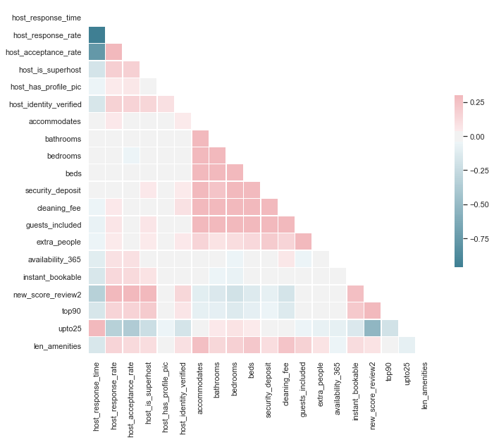

```python
sns.set(style="white")

# Compute the correlation matrix 'top90', 'upto25', .drop(['scrape_id', 'license'], axis=1)
corr = relevant_df.corr()

# Generate a mask for the upper triangle
mask = np.zeros_like(corr, dtype=np.bool)
mask[np.triu_indices_from(mask)] = True

# Set up the matplotlib figure
f, ax = plt.subplots(figsize=(11, 9))

# Generate a custom diverging colormap
cmap = sns.diverging_palette(220, 10, as_cmap=True)

# Draw the heatmap with the mask and correct aspect ratio
sns.heatmap(corr, mask=mask, cmap=cmap, vmax=.3, center=0,
            square=True, linewidths=.5, cbar_kws={"shrink": .5})
```

```python
A=relevant_df.corr().unstack().sort_values(ascending=False)
print('The correlation of the new_score_reviews against all:\n', A['new_score_review2'][1:-1])
```

```
The correlation of the new_score_reviews against all:
 top90                     0.749421
host_acceptance_rate      0.335193
host_is_superhost         0.329420
host_response_rate        0.306386
instant_bookable          0.269035
host_identity_verified    0.137262
len_amenities             0.081900
extra_people              0.038126
availability_365          0.033179
host_has_profile_pic      0.027935
guests_included           0.003832
security_deposit         -0.075282
accommodates             -0.103029
beds                     -0.119983
bathrooms                -0.138804
cleaning_fee             -0.179784
bedrooms                 -0.191699
host_response_time       -0.325291
dtype: float64
```

## Q2. Which features are highly correlated to the target variable?

# Comparation Graphs

```python
### defide them into 2 dataframe class ###

top_listings = listings_df[listings_df['new_score_review2'] >= np.percentile(listings_df['new_score_review2'],90)]
low_listings = listings_df[listings_df['new_score_review2'] <= np.percentile(listings_df['new_score_review2'],25)]

### Write function to reset index and add status to dataframe

def reset_idx_status(col_name,new_df_name_top,new_df_name_low):
    new_df_name_top= pd.DataFrame(top_listings[col_name].reset_index(drop = True))
    new_df_name_top['status'] = 'Top Performer'
    new_df_name_low = pd.DataFrame(top_listings[col_name].reset_index(drop = True))
    new_df_name_low['status'] = 'Low Performer'
    return new_df_name_top,new_df_name_low

### Host Acceptance Rate DataFrame ###

reset_idx_status('host_acceptance_rate','hostAR_top_performer','hostAR_low_performer')

#hostAR_top_performer = pd.DataFrame(top_listings['host_acceptance_rate'].reset_index(drop = True))
#hostAR_top_performer['status'] = 'Top Performer'

#hostAR_low_performer = pd.DataFrame(low_listings['host_acceptance_rate'].reset_index(drop = True))
#hostAR_low_performer['status'] = 'Low Performer'

hostAR = hostAR_low_performer.append(hostAR_top_performer).sample(frac=1)

### Identity verified.
reset_idx_status('host_identity_verified','identify_verified_top','identify_verified_low')

#identify_verified_top = pd.DataFrame(top_listings['host_identity_verified'].reset_index(drop = True))
#identify_verified_top['status'] = 'Top Performer'

#identify_verified_low = pd.DataFrame(low_listings['host_identity_verified'].reset_index(drop = True))
#identify_verified_low['status'] = 'Low Performer'

identify_verified = identify_verified_low.append(identify_verified_top).sample(frac=1)

### Host is Superhost DataFrame

reset_idx_status('host_is_superhost','superhost_top_performer','superhost_low_performer')

#superhost_top_performer = pd.DataFrame(top_listings['host_is_superhost'].reset_index(drop = True))
#superhost_top_performer['status'] = 'Top Performer'

#superhost_low_performer = pd.DataFrame(low_listings['host_is_superhost'].reset_index(drop = True))
#superhost_low_performer['status'] = 'Low Performer'

superhost = superhost_top_performer.append(superhost_low_performer).sample(frac=1)

### instant bookable

reset_idx_status('instant_bookable','instantBookable_top_performer','instantBookable_low_performer')

#instantBookable_top_performer = pd.DataFrame(top_listings['instant_bookable'].reset_index(drop = True))
#instantBookable_top_performer['status'] = 'Top Performer'

#instantBookable_low_performer = pd.DataFrame(low_listings['instant_bookable'].reset_index(drop = True))
#instantBookable_low_performer['status'] = 'Low Performer'

host_bookable = instantBookable_low_performer.append(instantBookable_top_performer).sample(frac=1)

### Host response Rate.

top_listings['host_response_time_str'] = top_listings['host_response_time'].apply(changeStr)
low_listings['host_response_time_str'] = low_listings['host_response_time'].apply(changeStr)

reset_idx_status('host_response_time_str','host_response_top','host_response_low')


#host_response_top = pd.DataFrame(top_listings['host_response_time_str'].reset_index(drop = True))
#host_response_top['status'] = 'Top Performer'

#host_response_low = pd.DataFrame(low_listings['host_response_time_str'].reset_index(drop = True))
#host_response_low['status'] = 'Low Performer'

host_response = host_response_low.append(host_response_top).sample(frac=1)

### **Host Response time.**

reset_idx_status('host_response_rate','host_responserate_top_performer','host_responserate_low_performer')

#host_responserate_top_performer = pd.DataFrame(top_listings['host_response_rate'].reset_index(drop = True))
#host_responserate_top_performer['status'] = 'Top Performer'

#host_responserate_low_performer = pd.DataFrame(low_listings['host_response_rate'].reset_index(drop = True))
#host_responserate_low_performer['status'] = 'Low Performer'

host_responserate = host_responserate_low_performer.append(host_responserate_top_performer).sample(frac=1)
# ---
percentage_low = list(host_responserate[host_responserate['status'] == 'Low Performer']['host_response_rate'].unique())
percentage_low.sort(reverse = True)
percentage_top = list(host_responserate[host_responserate['status'] == 'Top Performer']['host_response_rate'].unique())
percentage_top.sort(reverse = True)
host_responserate_fig = host_responserate[host_responserate['host_response_rate'].isin([1.0, 0.99, 0.96, 0.95, 0.94, 0.0])]

### collecting data into one array ###
data= []
data.append(hostAR)
data.append(identify_verified)
data.append(superhost)
data.append(host_bookable)
data.append(host_response)
data.append(host_responserate_fig)
```

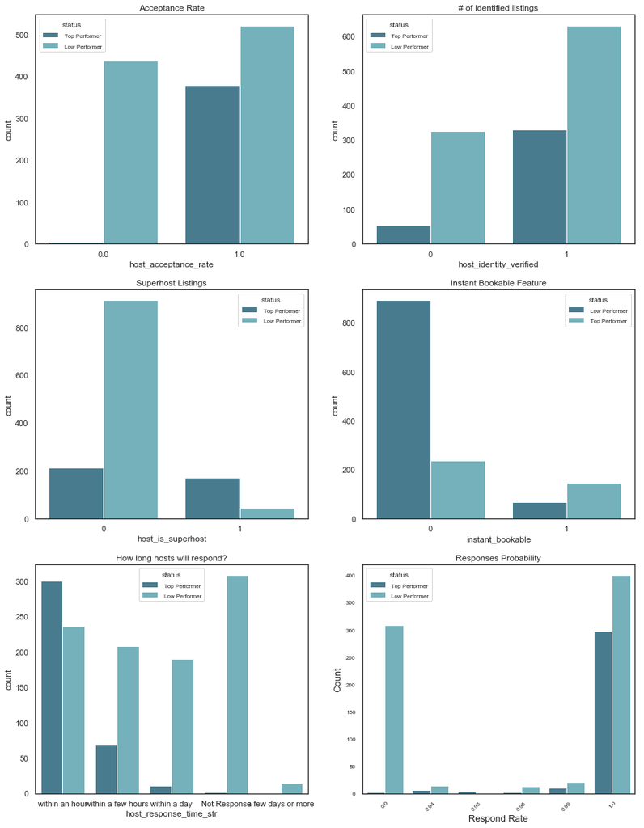

```python
#Visualizeation

fig, ax = plt.subplots(figsize=(15,20), nrows=3, ncols=2)
x_data= ['host_acceptance_rate','host_identity_verified','host_is_superhost','instant_bookable','host_response_time_str','host_response_rate']
title= ['Acceptance Rate','# of identified listings','Superhost Listings', 'Instant Bookable Feature', 'How long hosts will respond?' , 'Responses Probability']

x_axis= ['Percentage','Activate/Not','True/Not','Activate/Not', 'Respond Time', 'Respond Rate']
y_axis= ['Count']
cnt=0

for x in range(3):
    for y in range(2):

        ax[x][y].set_title(title[cnt], fontsize=12)
        sns.countplot(x=x_data[cnt], hue='status', data=data[cnt], palette='GnBu_d', orient='h', ax=ax[x][y])
        plt.setp(ax[x][y].get_legend().get_texts(), fontsize='8') # for legend text
        plt.setp(ax[x][y].get_legend().get_title(), fontsize='10') # for legend title
        plt.xticks(fontsize=8, rotation=45)
        plt.yticks(fontsize=8)
        plt.xlabel(x_axis[cnt], fontsize=13)
        p=plt.ylabel(y_axis[0], fontsize=13)

        cnt+=1
```

## Q3. How to become high performers in Airbnb listings?

Ans: 1. host_identity_verified: High performers tend to have their identity verified. Having identity verfied will help with the listing performance

1. host_response_time_str: High performers tend to respond quickly to inquires (mostly within a day with majority within an hour)
2. Respond Rate: Top performers almost always respond to inquiries.

```python
# Amenities change into reproduceable column.
listings_df['amenities']= df_s_list['amenities']
listings_df['array_amenities'] = listings_df['amenities'].apply(lambda x: createAmenities(x))
listings_df['len_amenities'] = listings_df['amenities'].apply(lambda x: len(createAmenities(x)))
```

[figure not shown]

```python
### table preparations

viz1 = top_listings[['len_amenities','id']].groupby(['len_amenities']).count().sort_values(by='id', ascending=False).head(7)
viz1['percentage'] = viz1['id'] / viz1['id'].sum()
viz2 = low_listings[['len_amenities','id']].groupby(['len_amenities']).count().sort_values(by='id', ascending=False).head(7)
viz2['percentage'] = viz2['id'] / viz2['id'].sum()

ids = [room for room in top_listings['id']]
viz_base1 = listings_df[listings_df['id'].isin(ids)].reset_index(drop = True)
arr = []
for row in range(viz_base1.shape[0]):
    arr = arr+viz_base1['array_amenities'][row]

test3 = Counter(arr)
viz3 = test3.most_common(10)
viz3 = pd.DataFrame(viz3).rename(columns={0:'name',1:'frequency'})
viz3['percentage'] = viz3['frequency'] / viz_base1.shape[0]
viz3.index = viz3['name']
viz3 = viz3.drop('name', axis = 1)

ids = [room for room in low_listings['id']]
viz_base2 = listings_df[listings_df['id'].isin(ids)].reset_index(drop = True)
arr = []
for row in range(viz_base2.shape[0]):
    arr = arr+viz_base2['array_amenities'][row]
test4 = Counter(arr)

viz4 = test4.most_common(10)
viz4 = pd.DataFrame(viz4).rename(columns={0:'name',1:'frequency'})
viz4['percentage'] = viz4['frequency'] / viz_base2.shape[0]
viz4.index = viz4['name']
viz4 = viz4.drop('name', axis = 1)

### visualization

fig, ax= plt.subplots(figsize= (30,17), nrows=2, ncols= 2)
sns.barplot(y=viz2.index.astype(str) + '_types',x=viz2['id'], ax=ax[0][0]).set_title('How much amenities does top 10% provide in every service', fontsize=11)
sns.barplot(y=viz1.index.astype(str) + '_types',x=viz1['id'], ax=ax[0][1]).set_title('How much amenities does Low Performer provide in every service', fontsize=11)
sns.barplot(y=viz4.index,x=viz4["percentage"], ax=ax[1][0]).set_title('The top miscellaneous provided by hosts (Low-Performancer Listings)', fontsize=11)
sns.barplot(y=viz3.index,x=viz3["percentage"], ax=ax[1][1]).set_title('The top miscellaneous provided by hosts (Top-Performer Listings)', fontsize=11)
```

# Q4: Which neighbourhood tends to have higher listing prices?

Ans: From the headmap below, we can see compare average listing prices by number bedrooms in different neighbourhood. The lighter the color is, the higher the average listing price is. For example, for studio listing, Holly Park and Industrial District tend to have higher listing prices. For six bedroom listings, Portage Bay has highest listing price of $750 per day.

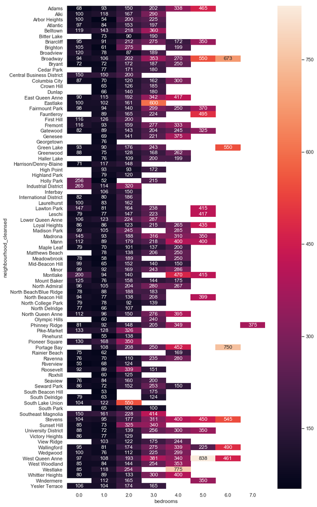

```python
df_s_list['price']=df_s_list['price'].map(lambda x: correction(x))
plt.figure(figsize=(10,20))
sns.heatmap(df_s_list.groupby(['neighbourhood_cleansed', 'bedrooms']).price.mean().unstack(),annot=True, fmt=".0f")
```

# Interpretation

Acceptance Rate: 50% of the low performer reject customers. Almost all top performers never reject customers. Host identify verified: Top performers have significantly higher chances to get themselves verified. Superhost: Even a lot of high performers are not superhosts Instant bookable: Top performers have higher chances to use instant bookable feature Hong long hosts will respond: Top performers have higher chances to respond within an hour. Most of them do. Response Rate: Top perfomers almost always repond to the customers

### Future Enhancement

The aboved analytics focus on data exploration and basic analytics derived from the dataset. For future enhancement, we could look at categorical variables to predict hot listings or not. Or we could create a model to predict the price.

```python
# examine categorical columns
#1. form a list of categrical variables: reomve all numerical categoreis previouly identified
df_s_list_1=df_s_list.drop(url_columns+unique_value_columns, axis = 1)
#cat_list= [i for i in df_s_list_1 if i not in listings_df]
#df_s_cat_list=df_s_list_1[cat_list]
```

```python
#3 Cleaning data to contain only object type
df_s_cat_list=df_s_list_1.select_dtypes(include=['object'])
```

```python
df_s_list_1.dtypes
```

[output not shown]